# Gym Injuries

## Analysis of suitability of data

An intervention has been proposed to offer a free Personal Training (PT) session aimed at teaching gym users to use the gym equipment safely. This analysis explores whether the currently available ACC data is suitable for informing such an intervention.

## Overview

While we are unable to determine which individuals would most benefit from PT sessions, we can quite effectively identify which individuals have the greatest risk of future gym injuries. We should prioritise collection of further relevant data to help us identify which injuries can best be prevented via the use of PT sessions, and which injuries are a higher priority to prevent. This will help us better target this intervention. In the meantime, we can use risk of future injury to help target any interventions we deploy.

## Introduction

### Problem statement

The proposed intervention is based on [a study](https://www.sciencedirect.com/science/article/pii/S240584402400656X) that found exposure to PT reduced incidence of gym-related injuries. However the intervention in the study appears to involve *all* gym sessions being PT sessions. The study also only focuses on a very narrow demographic group - healthy, young male adults. Whereas we’re proposing one introductory session on how to use gym equipment safely, which seems more inline with what happened with the control group in the study. We’re also looking to offer this over a range of age groups, sexes, and levels of health and ability. As such we can’t necessarily assume that use of PT will significantly reduce incidence of gym injuries.

### Key issues

The data available for analysis has several key variables missing. For example, we don’t have any information on severity of injuries, how frequently individuals attend the gym, what kinds of exercises they perform, and if they’ve had PT before. Other useful variables would include how frequently they receive PT, gender, sex at birth, and how frequently they lodge ACC claims.

Another point of consideration is the cost incurred by injuries. Although there is a mandate to reduce the severity and incidence of injuries in general, a focus on the most expensive injuries should be prioritised. This is because it will lead to cost savings for the organisation, freeing up more funds to invest in further injury prevention interventions. As such, data on the cost incurred by injuries would be valuable to improve the efficiency of the proposed intervention.

### The plan

While the information mentioned above is essential to ensure the intervention can be deployed efficiently, we may be requested to deploy the intervention anyway. To prepare for such a scenario, we explore the best we can do under certain assumptions. E.g. instead of modelling who will most benefit from the intervention, we model who is most at risk of receiving future gym injuries. This gives the programme manager a back-up option if they’re really keen to get something across the line ASAP. However we would advise against this, as there would be no guarantee of efficacy, and may not even lead to useful resulting data for further analysis.

### Other considerations

Some individuals experience multiple injuries, we should consider how we want to factor this into our analysis. For example, is it as beneficial to have an individual go from receiving one injury to receiving zero, as it would to have an individual going from receiving nine injuries to receiving eight?

Is explainability important for our model? We could build a well-tuned model that has high performance but has no intuitive rules for applying it. On the other hand, we could identify some key high level population groups to target. While this may not lead to the most efficient assignment of the intervention, it could help with explaining and rolling out the intervention, and ensuring that we adhere to the Algorithm Data Charter.

While we note that we have insufficient data to deploy this intervention effectively, we could use our budget of 500 PT sessions to run a data collection exercise. We can randomly assign 500 individuals to a PT session and see if they have reduced injury outcomes in comparison to a control group. In order to simultaneously maximise our expected reduction in injuries, we could oversample individuals we identify as being at high risk of injury for receiving the PT sessions. This approach would also assist in evaluating the efficacy of our intervention.

## Exploration of data

### Outcome of interest

We’re interested to understand which individuals have the greatest chance of experiencing an injury in the year following their data’s extraction date. Within our complete dataset, we have 80,000 observations, 5.0% of which experienced an injury in the year following their extraction date. This means our population of interest are quite a minority in our data, which could lead to class imbalance issues.

Although something to consider: while it would be inefficient to offer a PT session to someone who will not benefit from it, there’s no efficiency loss if we miss a good candidate. The main outcome we desire is that the 500 candidates we choose are suitable. As such, we should aim to minimise the false positive rate and not worry too much about the false negative rate, or overall accuracy. With this as our goal, resolving class imbalances is less of a priority.

### Numeric variables

#### High level summary

First we will check some high-level summaries of the numeric variables

|  | PersonACCId | age | deprivation_decile | num_gym_all | num_wgt_all | back_sprain_all | neck_sprain_all | rotator_sprain_all | shoulder_sprain_all | kneeleg_sprain_all | thoracic_sprain_all | hipthigh_sprain_all | arm_sprain_all | soft_tissue_all | lower_back_all | shoulder_all | neck_all | knee_all | high_leg_thigh_all | upper_back_spine_all | ankle_all | fracture_all | injured | accident_june_year |
| --- | --- | --- | --- | --- | --- | --- | --- | --- | --- | --- | --- | --- | --- | --- | --- | --- | --- | --- | --- | --- | --- | --- | --- | --- |
|  | Min. : 1 | Min. :-1044 | Min. : 1 | Min. : 0.00 | Min. : 0.00 | Min. : 0.0 | Min. : 0.0 | Min. :0.00 | Min. :0.0 | Min. :0.00 | Min. : 0.0 | Min. : 0.00 | Min. :0 | Min. : 0 | Min. : 0.0 | Min. : 0.0 | Min. : 0.0 | Min. : 0.0 | Min. : 0.0 | Min. : 0.0 | Min. : 0.0 | Min. : 0.0 | Min. :0.00 | Min. :2006 |
|  | 1st Qu.:20001 | 1st Qu.: 23 | 1st Qu.: 3 | 1st Qu.: 0.00 | 1st Qu.: 0.00 | 1st Qu.: 0.0 | 1st Qu.: 0.0 | 1st Qu.:0.00 | 1st Qu.:0.0 | 1st Qu.:0.00 | 1st Qu.: 0.0 | 1st Qu.: 0.00 | 1st Qu.:0 | 1st Qu.: 1 | 1st Qu.: 0.0 | 1st Qu.: 0.0 | 1st Qu.: 0.0 | 1st Qu.: 0.0 | 1st Qu.: 0.0 | 1st Qu.: 0.0 | 1st Qu.: 0.0 | 1st Qu.: 0.0 | 1st Qu.:0.00 | 1st Qu.:2011 |
|  | Median :40000 | Median : 39 | Median : 6 | Median : 0.00 | Median : 0.00 | Median : 0.0 | Median : 0.0 | Median :0.00 | Median :0.0 | Median :0.00 | Median : 0.0 | Median : 0.00 | Median :0 | Median : 1 | Median : 0.0 | Median : 0.0 | Median : 0.0 | Median : 0.0 | Median : 0.0 | Median : 0.0 | Median : 0.0 | Median : 0.0 | Median :0.00 | Median :2014 |
|  | Mean :40000 | Mean : 41 | Mean : 6 | Mean : 0.06 | Mean : 0.02 | Mean : 0.4 | Mean : 0.2 | Mean :0.08 | Mean :0.1 | Mean :0.08 | Mean : 0.1 | Mean : 0.07 | Mean :0 | Mean : 2 | Mean : 0.5 | Mean : 0.3 | Mean : 0.2 | Mean : 0.3 | Mean : 0.2 | Mean : 0.1 | Mean : 0.3 | Mean : 0.3 | Mean :0.05 | Mean :2013 |
|  | 3rd Qu.:60000 | 3rd Qu.: 57 | 3rd Qu.: 8 | 3rd Qu.: 0.00 | 3rd Qu.: 0.00 | 3rd Qu.: 0.0 | 3rd Qu.: 0.0 | 3rd Qu.:0.00 | 3rd Qu.:0.0 | 3rd Qu.:0.00 | 3rd Qu.: 0.0 | 3rd Qu.: 0.00 | 3rd Qu.:0 | 3rd Qu.: 3 | 3rd Qu.: 1.0 | 3rd Qu.: 0.0 | 3rd Qu.: 0.0 | 3rd Qu.: 0.0 | 3rd Qu.: 0.0 | 3rd Qu.: 0.0 | 3rd Qu.: 0.0 | 3rd Qu.: 0.0 | 3rd Qu.:0.00 | 3rd Qu.:2016 |
|  | Max. :80000 | Max. : 116 | Max. :10 | Max. :11.00 | Max. :12.00 | Max. :16.0 | Max. :15.0 | Max. :7.00 | Max. :7.0 | Max. :9.00 | Max. :17.0 | Max. :13.00 | Max. :1 | Max. :69 | Max. :17.0 | Max. :13.0 | Max. :15.0 | Max. :12.0 | Max. :20.0 | Max. :17.0 | Max. :17.0 | Max. :15.0 | Max. :1.00 | Max. :2016 |
|  |  | NA's :1 | NA's :4561 |  |  |  |  |  |  |  |  |  | NA's :30000 |  |  |  |  |  |  |  |  |  |  |  |

Some things of note:

- age has one NA and some negative values
- deprivation has 4,561 NAs
- arm_sprain_all has 30,000 NAs
- Someone’s had 69 soft tissue injuries! And they’re only 27 years old!

It appears as though we have some outliers/erroneous values, and we have missing values which will need to be imputed. We could also set anomalous values to NA, and impute them as well.

With arm_sprain_all it is possible that the NAs should be zero, but examining the data, 0 is already the modal value - and the max value is 1. It seems more likely that the values greater than 1 have somehow been dropped. It will be challenging to reliably impute this, so unless we can resource this data, we might be better placed to just drop it.

#### Correlations

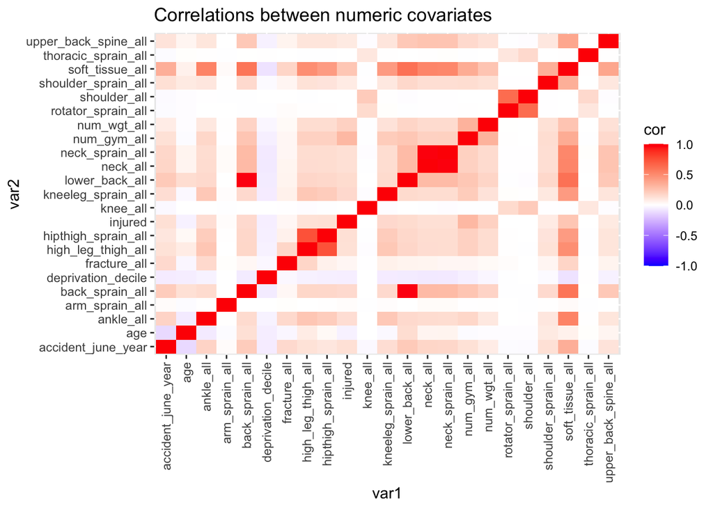

It appears there are no silver bullets for correlation with outcome variable “injured”. And we do see some examples of colinearity to be cautious of:

- shoulder vs rotator_sprain
- num_wgt vs num_gym
- neck_sprain vs neck
- hipthigh_sprain vs high_leg_thigh
- lower_back vs back_sprain
- soft_tissue seems to have high correlations with many variables
- In general there are strong correlations between the majority of injury variables

The correlations between age and the counts of historic injuries are quite low. This is surprising, as one would expect that as you age, your cumulative total of past injuries would increase.

It’s surprising to see that shoulder_sprain and shoulder aren’t strongly correlated, when most sprains seem to correlate strongly with total injuries in the corresponding body part.

The most strongly correlated variables with our outcome of interest are:

```
# A tibble: 10 × 2
   var                  cor
   <chr>              <dbl>
 1 num_gym_all        0.301
 2 soft_tissue_all    0.243
 3 num_wgt_all        0.194
 4 kneeleg_sprain_all 0.160
 5 back_sprain_all    0.156
 6 lower_back_all     0.149
 7 ankle_all          0.140
 8 neck_all           0.133
 9 accident_june_year 0.131
10 neck_sprain_all    0.130
```

Digging in to some of the unusual observations, we find there is indeed something strange happening with shoulder injury counts. Some people have more shoulder sprains than shoulder injuries - there’s a potential risk of erroneous values, or perhaps some column labels have been swapped.

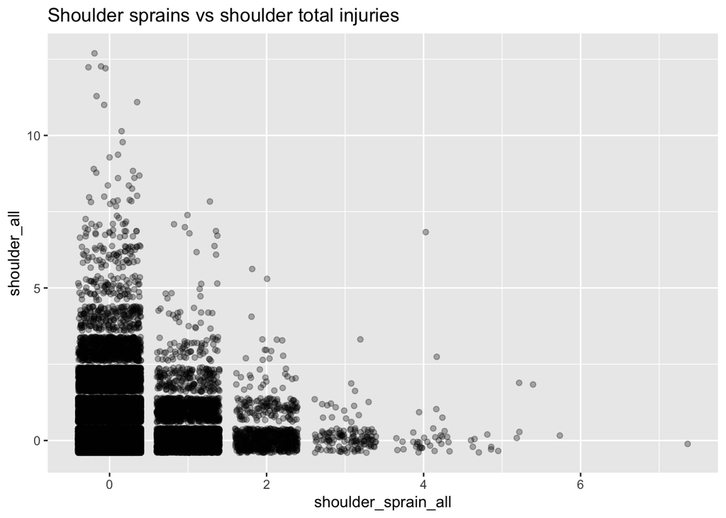

We should also check other pairings of total injuries vs just sprains, as sprains should never exceed total injuries (assuming sprains count as a type of injury).

We also observed an unexpected relationship between age and injury counts.

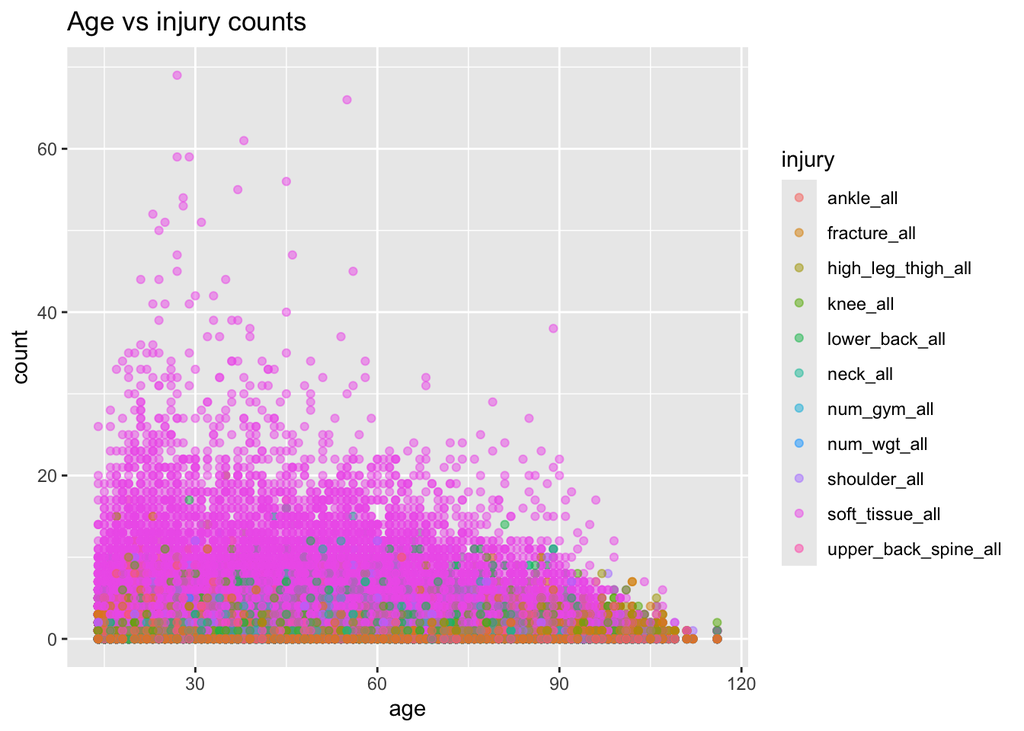

There are a lot of high injury counts for younger individuals, and they largely seem to be soft tissue injuries. Do we count the same injury multiple times if it affects multiple soft tissues? Do we have worse record keeping for older individuals?

### Categorical variables

Now we explore injury rates by categorical variables. Note that we will also explore relationships between injury outcomes and binned numeric variables, as there is a risk of non-linearity that will obscure interactions between injury outcomes and numeric variables.

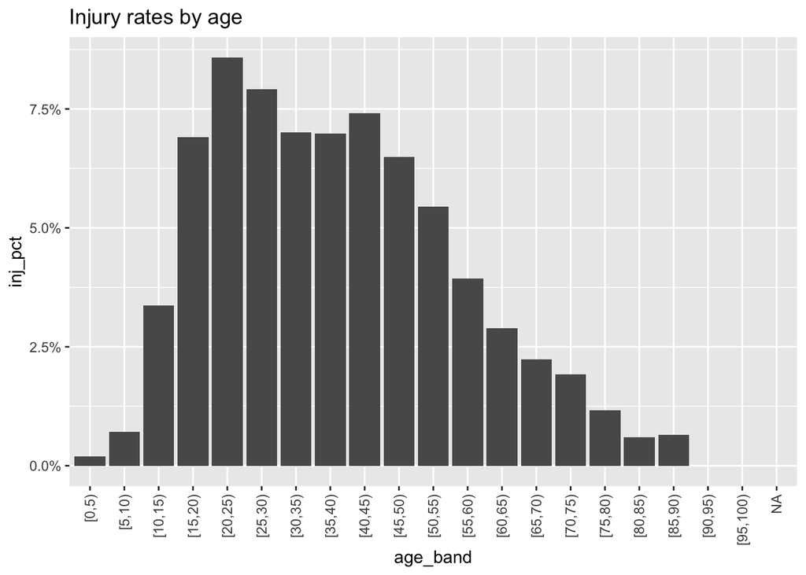

We do indeed see a non-linear relationship between injury rates and age, which peaks in 20-24 age group. There do seem to be some unusual data points showing up here, though.

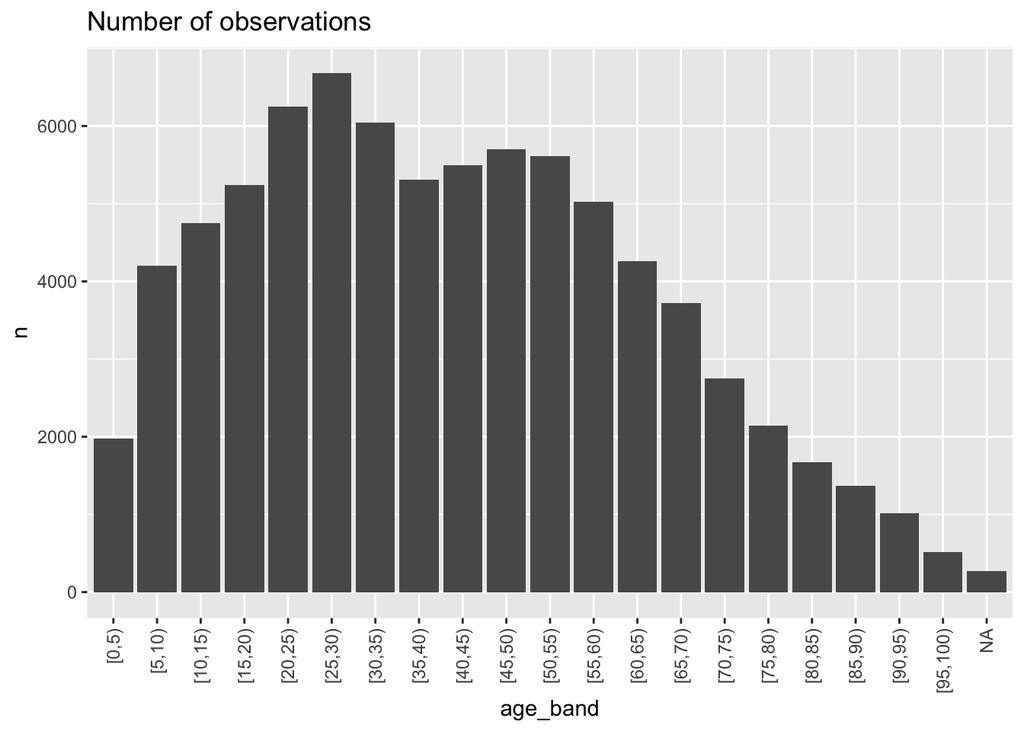

There is a surprisingly large number of 0-4 year olds. Either there are some very muscly babies out there, or there are deeper issues with age data that will need to get resolved. The youngest age I have found gyms in NZ allow is 14 years old. Perhaps we set all values below this to NA, and impute them. We should also check how age is derived - is there some systemic issue that could lead to more age values being incorrect?

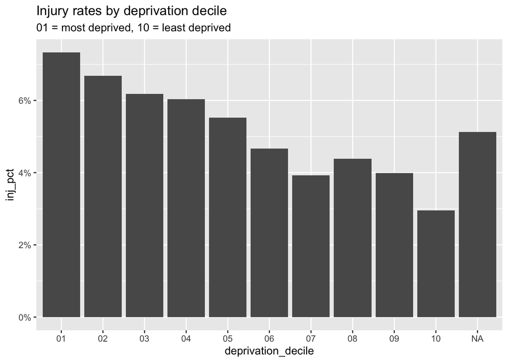

We observe that injury rates decrease as dep decile increases, however it’s not completely linear. Injury rates slightly increase in the 8-9 area.

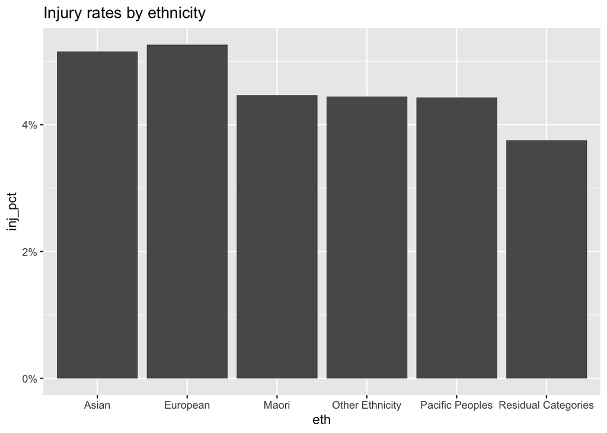

There seems to be a weak interaction between ethnicity and injury outcomes.

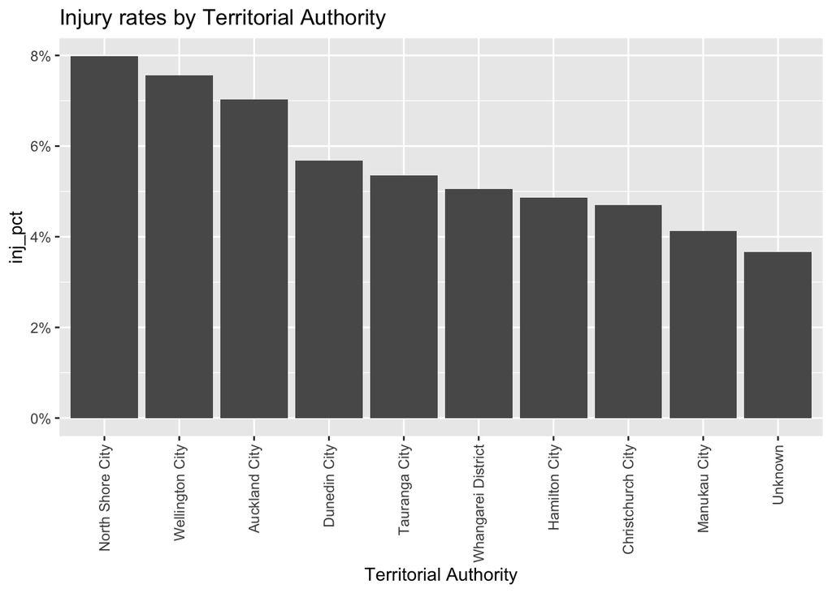

We do see some large differences by Territorial Authority. Although surprisingly few TLAs are featured, NZ has 67 in total. Do most of these not have gyms, or do we only count the top 9 and put the rest into Unknown as a residual category? Otherwise this could suggest that we’re missing areas from the training data.

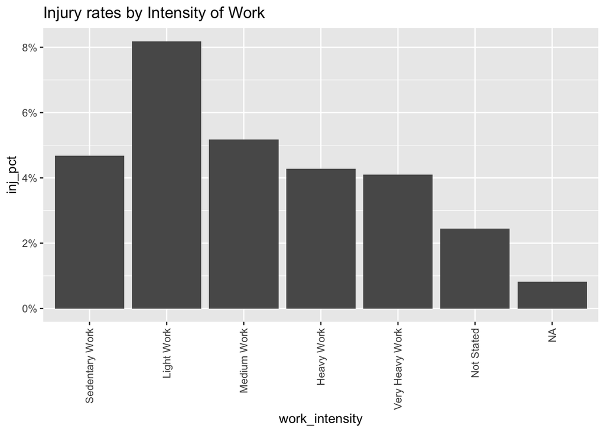

Intensity of Work is an ordinal variable, ranging from sedentary (least intense) to very heavy (most intense) work. However injury rates don’t follow a monotone relationship, with light work individuals having the highest injury rate. Therefore it may not be beneficial to treat it as ordinal in our modelling. We will need to impute the NAs, should we impute Not Stated as well? There could be a meaningful difference between Not Stated and NAs, e.g. Not Stated could include individuals who are not currently working. For now we should only impute NAs.

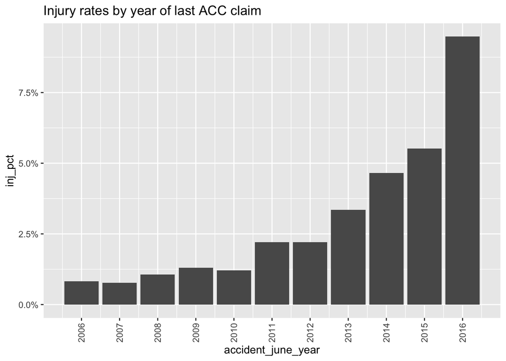

Injury rates increase with respect to how recent the last ACC claim was. This makes some sense, the longer one goes without making ACC claims, the less prone they are to getting injured. Having a recent claim might indicate a high frequency of claims, so will be a good predictor of making future claims.

## Model construction

We aim to build a model to inform which individuals are best suited for receiving the free Personal Training (PT) session. This task will have to rely on some certain assumptions, where we don’t have adequate data to inform the modelling:

- We do not know if the individuals reporting injuries in this data have already had PT sessions. Those that have already had them may benefit less from them.
- We don’t have data to inform which demographics receive the most benefit from PT sessions.

As such we have to assume that the current uptake rates of PT services and the benefits received from PT services are independent of all variables we consider.

Our analysis above indicates high rates of non-linearity between covariates and our desired outcome variable. While a binomial distribution is a tempting choice for the model fit, it will be challenging to get it to work with the non-linearity and interaction effects of our covariates. We could resolve these by using principal components for correlated variables, but in the first instance it will be easier to try a random forest.

Note that for now we will exclude all observations with NA or erroneous values. For future iterations, we can look to resolve priority missing/erroneous variables with imputation.

```
Call:
 randomForest(x = x_train, y = y_train, xtest = x_test, ytest = y_test,      ntree = 100, classwt = c(Y = 1, N = weights$N), importance = T,      keep.forest = T)
               Type of random forest: classification
                     Number of trees: 100
No. of variables tried at each split: 4

        OOB estimate of  error rate: 5.56%
Confusion matrix:
      N   Y class.error
N 37020 146 0.003928322
Y  2045 163 0.926177536
                Test set error rate: 5.36%
Confusion matrix:
      N  Y class.error
N 24743 78   0.0031425
Y  1330 99   0.9307208
```

```
Most important variables:
```

```
                            N         Y MeanDecreaseAccuracy MeanDecreaseGini
num_gym_all        -7.0348439 39.038343            14.668311        1383.8687
accident_june_year -7.1167359 30.875946             1.295773        2011.3225
soft_tissue_all    -2.0980429 24.126190             4.505741        2513.9158
num_wgt_all         8.0254738 22.047256            20.288970         434.4295
age                10.8600902 21.604078            16.840606        3558.9157
lower_back_all      2.5017509  6.107351             3.291651         769.2049
high_leg_thigh_all  0.3973553  4.287132             2.271131         402.7900
deprivation_decile -1.1378450  2.918932            -0.163506        1655.6253
tla                 0.6648647  1.984193             1.309959        1123.0830
work_intensity     12.5150177  1.854343            12.391874        1270.5131
```

We have also found the most important variables in identify a future injury outcome - things like the count of previous gym injuries, the recency of the last ACC claim, soft tissue injury counts, count of weight-lifting injuries, and age. Many of these are as we expected. Some things have lower significance than expected, like work_intensity. This might correlate with other significant variables, which reduces its explanatory power.

## Next steps

To improve performance, we could explore alternative models, or fine-tune the model parameters of the random forest.

We are currently dropping 18% of observations due to data issues, use of imputation could improve this. Although most of these are being dropped due to suspicious age values (<14), so ensuring age is being calculated correctly should be a priority.

We are also dropping observations due to missing deprivation, but this is not an important variable in the model. We could instead remove this variable from our training data, and retain those ~4,000 observations.